# Agrégation sociale

Author

C. Grasland

```r
library(knitr)
options(max.print="80")
opts_chunk$set(echo=TRUE,
               cache=FALSE,
               prompt=FALSE,
               tidy=FALSE,
               comment=NA,
               message=FALSE,
               warning=FALSE,
               options(scipen=999))

# Selection de packages tidyverse
library(dplyr,quietly = T,warn.conflicts = F,verbose = F)
library(tidyr,quietly = T,warn.conflicts = F,verbose = F)
library(ggplot2,quietly = T,warn.conflicts = F,verbose = F)

# packages de cartographie
library(sf,quietly = T, verbose=F)
# Packages d'enquête
#library(xtable)
#library(survey)
library(questionr)
```

## Objectifs

Dans ce premier exercice on ne va pas s’intéresser à la **géographie** des logements sociaux mais à leur **sociologie**. On va donc croiser la variable Y = ménages résidant dans un logement social avec d’autres variables X1 ..Xn décrivant les attributs des ménages et chercher s’il existe des relations statistiquement significatives.

### Formuler des questions ou des hypothèses

Qu’elles soient justes ou fausses, les hypothèses permettent de cadrer l’analyse.

1. **Diplôme et logement social** : Les logements sociaux sont-ils réservés aux ménages les moins diplômés ?
2. **Âge et logement social** : Les logements sociaux sont-ils réservés aux jeunes ménages ?
3. **Logement social, âge et diplômes** : Les personnes diplômés quittent-elles les logements sociaux dès que leurs revenus progressent

### Organiser le travail

Sutout dans le cadre d’un groupe !

1. **Ne collecter que les données utiles pour répondre aux questions posées** afin de ne pas être tenté de partir dans toutes les directions
2. **Archiver soigneusement les programmes et les résultats** afin de pouvoir reproduire ultérieurement les analyses sur une autre période, un autre territoire
3. **Ne pas attendre d’avoir accumulé tous les résultats pour les commenter** car l’analyse peut suggérer des erreurs ou ouvrir de nouvelles pistes.
4. **Partir des questions et non pas des outils** faute de quoi on va trouver des réponses (42 …) sans savoir quelle est la question.

### Chargement des données

```r
tab_ind<-readRDS("res/tabmen.RDS")

head(tab_ind[,1:5],2)
```

```
FALSE   X COMMUNE   ARM      IRIS ACHL
FALSE 1 1   13055 13201 132010101  B11
FALSE 2 2   13055 13201 132010101  A12
```

### Réviser ses cours de statistiques …

Selon la nature des variables X et Y vous devrez faire appel à des méthodes statistiques différentes. Nous allons donner ici deux exemples différents

## Exemple 1 : Logement HLM et diplôme

### Préparation de l’analyse

- Soit la relation entre logement en HLM (Y) et Diplôme le plus élevé du chef de ménage (X). Il s’agit de deux variables **catégorielles** (= qualitatives) que l’on va typiquement mettre en relation à l’aide d’un **tableau de contingence** et d’un **test du chi-2**. L’analyse statistique est simple sous R mais il faut tenir compte de trois difficultés
- Le choix de la **population de référence** est important. Ici on va sélectionner les ménages dont la personne de référence est âgée de 25-39 ans
- la sélection ou le regroupement des **diplômes** est également important car cela va influer sur les résultats du test.
- la **pondération des individus** doit également être prise en compte puisque le recensement est basé sur un sondage

### Sélection des individus et des variables

```r
tab_sel<- tab_ind %>%
  filter(AGEMEN8 == "25") %>%
  select(DIPLM,HLML, IPONDL)


knitr::kable(head(tab_sel,4))
```

| DIPLM | HLML | IPONDL |
| --- | --- | --- |
| 15 | 2 | 2.48657 |
| 15 | 2 | 2.48657 |
| 18 | 2 | 2.48657 |
| 18 | 2 | 2.48657 |

### Recodage des modalités

On cherche le code des modalités CS1 ezt HLML dans le fichier des métadonnées

```r
meta<-readRDS("res/tabmen_meta.RDS")
metasel <- meta %>% filter(COD_VAR %in% c("DIPLM", "HLML"))
kable(metasel[,c(1,3,4)])
```

| COD_VAR | COD_MOD | LIB_MOD |
| --- | --- | --- |
| DIPLM | 01 | Pas de scolarité ou arrêt avant la fin du primaire |
| DIPLM | 02 | Aucun diplôme et scolarité interrompue à la fin du primaire ou avant la fin du collège |
| DIPLM | 03 | Aucun diplôme et scolarité jusqu’à la fin du collège ou au-delà |
| DIPLM | 11 | CEP (certificat d’études primaires) |
| DIPLM | 12 | BEPC, brevet élémentaire, brevet des collèges, DNB |
| DIPLM | 13 | CAP, BEP ou diplôme de niveau équivalent |
| DIPLM | 14 | Baccalauréat général ou technologique, brevet supérieur, capacité en droit, DAEU, ESEU |
| DIPLM | 15 | Baccalauréat professionnel, brevet professionnel, de technicien ou d’enseignement, diplôme équivalent |
| DIPLM | 16 | BTS, DUT, Deug, Deust, diplôme de la santé ou du social de niveau bac+2, diplôme équivalent |
| DIPLM | 17 | Licence, licence pro, maîtrise, diplôme équivalent de niveau bac+3 ou bac+4 |
| DIPLM | 18 | Master, DEA, DESS, diplôme grande école niveau bac+5, doctorat de santé |
| DIPLM | 19 | Doctorat de recherche (hors santé) |
| DIPLM | YY | Hors résidence principale |
| HLML | 1 | Logement appartenant à un organisme HLM |
| HLML | 2 | Logement n’appartenant pas à un organisme HLM |
| HLML | Y | Hors résidence principale |

On recode les modalités des deux variables en regroupant certaines CSP

```r
tab_sel$HLML<-as.factor(tab_sel$HLML)
levels(tab_sel$HLML)<-c("HLM-O","HLM-N",NA)
tab_sel$DIPLM<-as.factor(tab_sel$DIPLM)
levels(tab_sel$DIPLM) <- c("< BAC","< BAC","< BAC","< BAC","< BAC","< BAC",
                         "BAC","BAC",
                         "BAC+123","BAC+123","> BAC+3","> BAC+3",NA)
table(tab_sel$DIPLM)
```

```
FALSE
FALSE   < BAC     BAC BAC+123 > BAC+3
FALSE   12206    7423   10379    9766
```

```r
knitr::kable(head(tab_sel,3))
```

| DIPLM | HLML | IPONDL |
| --- | --- | --- |
| BAC | HLM-N | 2.48657 |
| BAC | HLM-N | 2.48657 |
| > BAC+3 | HLM-N | 2.48657 |

### Création du tableau de contingence non pondéré (FAUX)

La solution la plus simple semble être l’instruction *table()*

```r
tab_cont<-table(tab_sel$HLML,tab_sel$DIPLM)

knitr::kable(addmargins(tab_cont))
```

|  | < BAC | BAC | BAC+123 | > BAC+3 | Sum |
| --- | --- | --- | --- | --- | --- |
| HLM-O | 3314 | 1319 | 931 | 439 | 6003 |
| HLM-N | 8892 | 6104 | 9448 | 9327 | 33771 |
| Sum | 12206 | 7423 | 10379 | 9766 | 39774 |

### Création du tableau de contingence pondéré (JUSTE)

On pondère avec *wtd.table()* du package *questionr*.

### programme

```r
library(questionr)
tab_cont_wtd<-wtd.table(tab_sel$HLML,tab_sel$DIPLM,
                        weights = tab_sel$IPONDL)

knitr::kable(round(addmargins(tab_cont_wtd),0))
```

|  | < BAC | BAC | BAC+123 | > BAC+3 | Sum |
| --- | --- | --- | --- | --- | --- |
| HLM-O | 7538 | 2898 | 2096 | 960 | 13492 |
| HLM-N | 22318 | 14339 | 21648 | 21557 | 79862 |
| Sum | 29855 | 17237 | 23744 | 22518 | 93354 |

### Comparaison des résultats en %

- Tableau non pondéré … légèrement faux !

|  | < BAC | BAC | BAC+123 | > BAC+3 | All |
| --- | --- | --- | --- | --- | --- |
| HLM-O | 27.2 | 17.8 | 9 | 4.5 | 15.1 |
| HLM-N | 72.8 | 82.2 | 91 | 95.5 | 84.9 |
| Total | 100.0 | 100.0 | 100 | 100.0 | 100.0 |

- Tableau pondéré … juste !

|  | < BAC | BAC | BAC+123 | > BAC+3 | All |
| --- | --- | --- | --- | --- | --- |
| HLM-O | 25.2 | 16.8 | 8.8 | 4.3 | 14.5 |
| HLM-N | 74.8 | 83.2 | 91.2 | 95.7 | 85.5 |
| Total | 100.0 | 100.0 | 100.0 | 100.0 | 100.0 |

### Visualisation du tableau de contingence

On choisit l’orientation du tableau et on l’affiche avec plot()

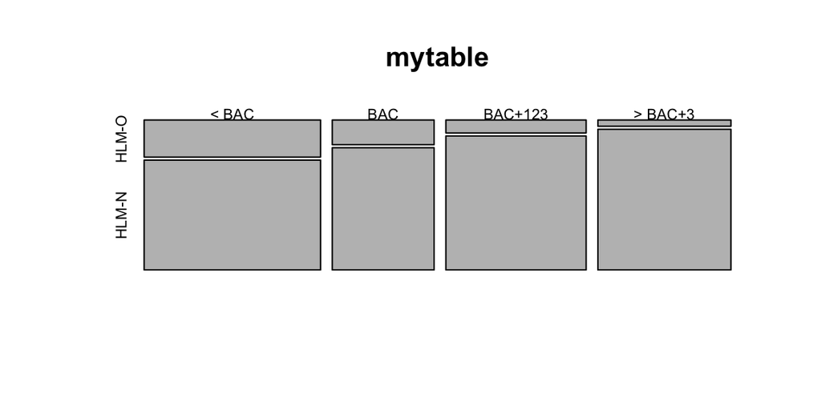

```r
mytable<-wtd.table(tab_sel$DIPLM,tab_sel$HLML,weights = tab_sel$IPONDL)
plot(mytable)
```

Tant qu’à faire, on améliore la figure avec des paramètres supplémentaires :

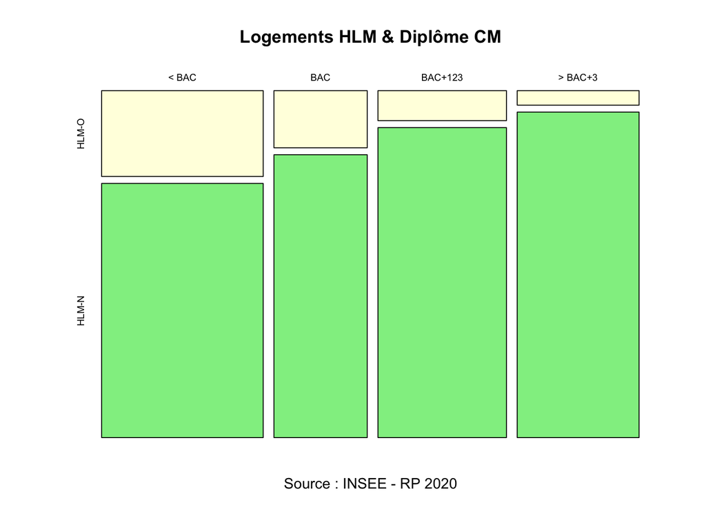

```r
plot(mytable,
     main = "Logements HLM & Diplôme CM",
     sub = "Source : INSEE - RP 2020",
     col=c("lightyellow","lightgreen"))
```

### Test du Chi-deux

Ce test se réalise facilement sur le tableau de contingence avec l’instruction *chisq.test()* :

```r
mytest<-chisq.test(mytable)
mytest
```

```
    Pearson's Chi-squared test

data:  mytable
X-squared = 5389.3, df = 3, p-value < 0.00000000000000022
```

La lecture de la p-value permet de savoir s’il existe une relation significative entre les deux variables.

### Visualisation des résidus

Lorsque la relation est significative, on peut visualiser les cases les plus exceptionnelles avec *mosaicplot( …, shade = T)*

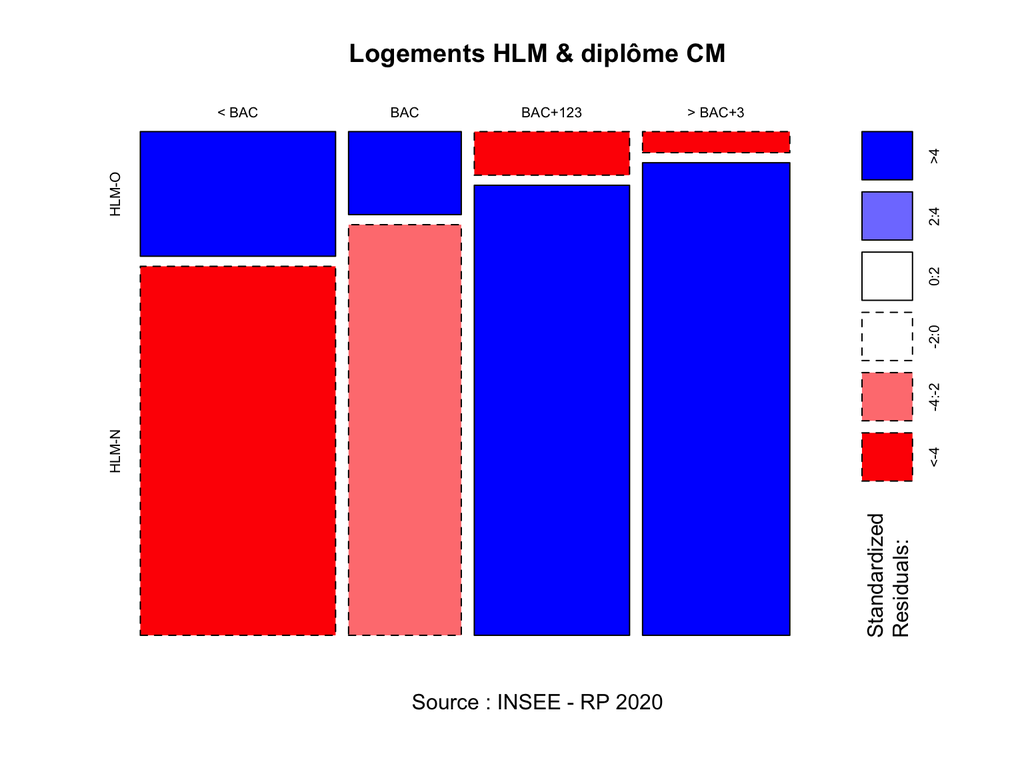

## Exemple 2 : HLM et ancienneté d’occupation

Dans ce deuxième exemple, on se propose d’analyser si les habitants des HLM y résident depuis plus longtemps que les habitants d’autres types de logements. On va donc calculer leur ancienneté moyenne puis déterminer à l’aide d’un test d’égalité des moyennes s’il y a des différences significatives.

Nous devons comme précédemment tenir compte des pondérations

### Préparation des données

```r
tab_sel<- tab_ind  %>%
  select(ANEM,HLML,IPONDL) %>%
  filter(ANEM != "999") %>%
  mutate(ANEM = as.numeric(ANEM))

tab_sel$HLML<-as.factor(tab_sel$HLML)
levels(tab_sel$HLML)<-c("Oui","Non")
head(tab_sel)
```

```
  ANEM HLML  IPONDL
1   11  Non 2.48657
2   12  Non 2.48657
3   10  Non 2.48657
4   81  Non 2.48657
5   10  Non 2.48657
6    1  Non 2.48657
```

### Statistiques non pondérées

On peut commencer par une description rapide sans pondération :

```r
tapply(tab_sel$ANEM, tab_sel$HLML, summary)
```

```
$Oui
   Min. 1st Qu.  Median    Mean 3rd Qu.    Max.
   0.00    3.00    8.00   13.73   20.00   88.00

$Non
   Min. 1st Qu.  Median    Mean 3rd Qu.    Max.
    0.0     2.0     5.0    12.1    18.0   101.0
```

On découvre - avec surprise - que l’ancienneté d’occupation des ménages qui résdient en HLM est plus importante que celle des autres ménages. Est-ce une erreur liée à l’absence de pondération ?

### Moyenne et ecart-types pondérés

On calcule la moyenne et l’écart-type pondérés à l’aide du package `weights`.

```r
library(weights,quietly = T, verbose=F)
tab_sel %>% group_by(HLML) %>%
           summarise(moyenne=wtd.mean(ANEM,IPONDL),
                     variance = wtd.var(ANEM,IPONDL),
                     ectype = sqrt(variance))
```

```
# A tibble: 2 × 4
  HLML  moyenne variance ectype
  <fct>   <dbl>    <dbl>  <dbl>
1 Oui      15.1     202.   14.2
2 Non      13.5     228.   15.1
```

Les valeurs sont différentes mais la conclusion demeure la même : les ménages qui résident en HLM y sont depuis plus longtemps que les autres. Toutefois l’écart-type est également tr§s grand ce qui incité à visualiser les distributions.

### Boxplot

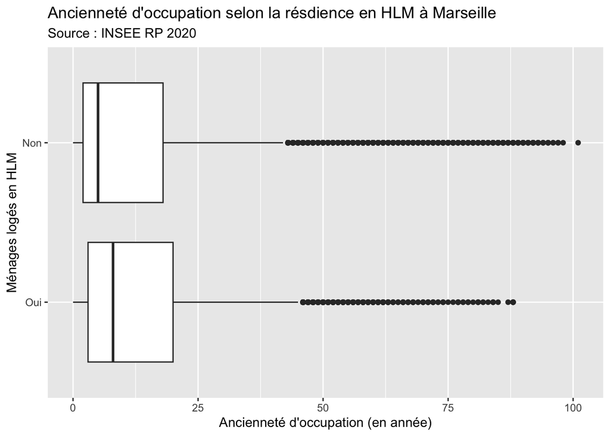

```r
ggplot(data = tab_sel)+ aes(x=ANEM, y = HLML) +
      geom_boxplot() +
      scale_x_continuous("Ancienneté d'occupation (en année)") +
      scale_y_discrete("Ménages logés en HLM") +
      ggtitle("Ancienneté d'occupation selon la résdience en HLM à Marseille",
              subtitle = "Source : INSEE RP 2020") +
      theme_gray()
```

Il y a effectivement un décalage, aussi bien pour la moyenne, la médiane et les quartiles. Pour conclure on va donc réaliser un test.

### Test d’égalité des moyennes

```r
t.test(ANEM~HLML, data=tab_sel)
```

```
    Welch Two Sample t-test

data:  ANEM by HLML
t = 17.777, df = 41032, p-value < 0.00000000000000022
alternative hypothesis: true difference in means between group Oui and group Non is not equal to 0
95 percent confidence interval:
 1.447961 1.806821
sample estimates:
mean in group Oui mean in group Non
         13.72549          12.09810
```

On peut conclure cette fois-ci sans risque d’erreur (p < 0.001) que les habitants des HLM y résident depuis plus longtemps que ceux des autres logements à Marseille en 2020.